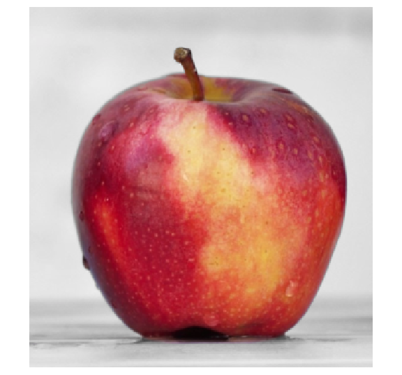

The plot below shows the very same picture again but with modified color information. The left apple has no color at all (the chroma of all pixels is set to 0), the apple on the right hand side is blue instead of red - something which does not exist in nature. However, our visual system is still capable of identifying the object within a few hundreds of a second.

One reason is that our visual system is very efficient processing smallest differences in luminance. Our retina consists of about 5 to 6 times more cone than rod cells which are very sensitive the lightness of an object. The rod cells, which are responsible to distinguish between different colors, are much less common and only concentrated in a relatively small are in the center of the retina. Large parts of the visual information is gathered via luminance. Our brain converts the luminance information an impression of a shape of the object, in this case \u2018an apple\u2019. Even without color (left image) or with unnatural color attributes (right image) we can still easily identify the apple. The color on top is used as an additional attribute to check if the apple is mellow and sweet, bitter, or might even be poisonous, but is not really necessary identify the apple itself.

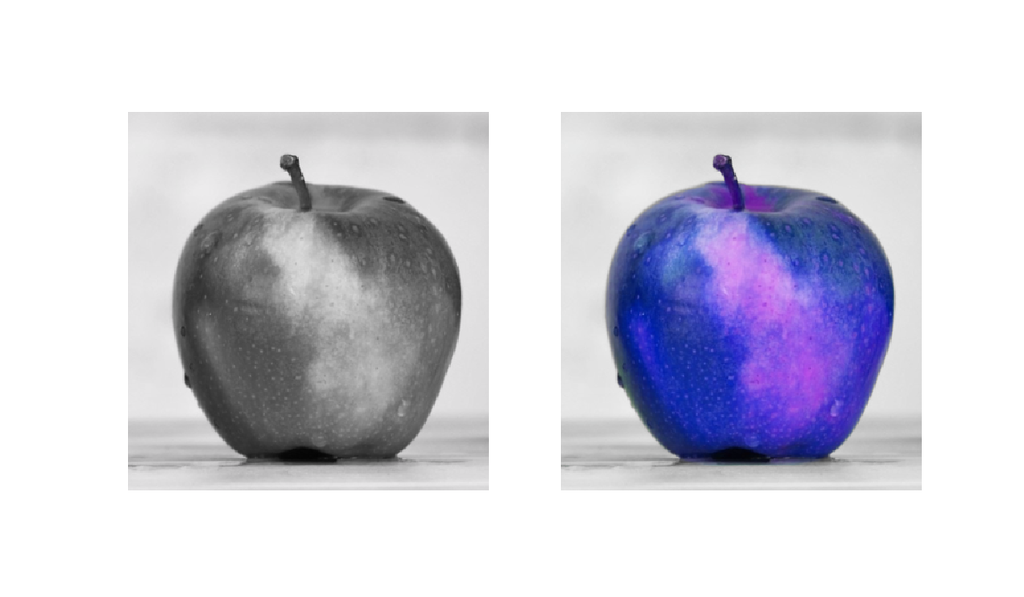

The next image shows the same apple again, but the luminance is artificially set constant. Thus, we have to classify the object solely based on the color and the colorfulness which is rather tricky.

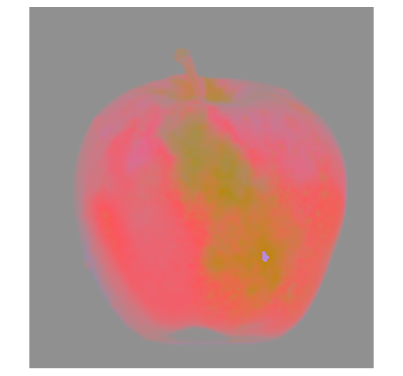